# Script No. 2

Marlene Kammerer

12 Oktober 2023

# Network centrality

## Tutorial

### Content

- Load packages
- Load the network data
- Create network objects
- calculate networks centrality statistics

### Install & load packages

Again, we work with the`igraph` package.

Do not forget to call `library(igraph)`.

```r
# install.packages("igraph") # to install the package
library(igraph) # to load the package
```

### Load the network data

In this tutorial, we work with the US data again. For your exercises, you will work with a brand new Swiss dataset.

For more information on the US data you may have a look at ([Kammerer et al. 2021]https://onlinelibrary.wiley.com/doi/10.1111/psj.12422)

```r
## Attributes

att.usa <- read.csv2("Data/usa_attributes.csv", header=TRUE)

## Collaboration network

coll.usa <- read.csv2("Data/usa_collaboration.csv", header=TRUE)
rownames(coll.usa) <- coll.usa$ID
coll.usa$ID <- NULL

## Influence network

inf.usa <- read.csv2("Data/usa_influence.csv", header = TRUE, stringsAsFactors=FALSE)
rownames(inf.usa) <- inf.usa $ID
inf.usa$ID <- NULL

## Scientific information network

sci.usa <- read.csv2("Data/scientific-information_USA.csv", header = TRUE, stringsAsFactors=FALSE)
rownames(sci.usa) <- sci.usa$ID
sci.usa$ID <- NULL
```

### Explore data sets

As usual, make sure that your datasets are correctly loaded. Check if there are NAs or any other issues that need to be resolved first.

```r
View(att.usa)
View(coll.usa)
View(inf.usa)
View(sci.usa)
```

### Create network objects

As usual we have to create network objects! This means to transform the data first into a matrix object (not dataframe) and then into a graph object.

#### First: Create matrices from data frames (only for “networks”)

```r
coll.mat <- as.matrix(coll.usa)
inf.mat <- as.matrix(inf.usa)
sci.mat <- as.matrix(sci.usa)

# How to deal with NAs?? For the moment, we will recode them to 0. But, at later points we also discuss different strategies for treating NAs.

coll.mat[is.na(coll.mat)] <- 0
inf.mat[is.na(inf.mat)] <- 0
sci.mat[sci.mat == 98] <- 0
```

#### Second: Create network object and visualize it in a first very simple plot

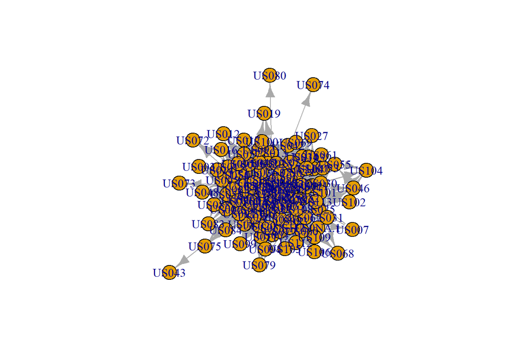

```r
coll.mat <- as.matrix(coll.usa)
coll.net <- graph.adjacency(coll.mat, mode="directed", diag=FALSE)
plot(coll.net)
```

### Explore network

Recall, in the last week, we did some basic analyses …

```r
# number of nodes and edges

vcount(coll.net)
```

```
## [1] 113
```

```r
ecount(coll.net)
```

```
## [1] 1269
```

```r
# cliques

table(sapply(cliques(coll.net), length))
```

```
##
##    1    2    3    4    5    6    7    8    9   10
##  113 1110 4016 7276 7577 4872 1992  512   77    5
```

```r
# dyads

dyad.census(coll.net)
```

```
## $mut
## [1] 159
##
## $asym
## [1] 951
##
## $null
## [1] 5218
```

```r
# triads

triad.census(coll.net)
```

```
##  [1] 140756  59411   8155  10235   2524   3084   1031   4461   1642     36
## [11]    463    285   1220    248    432    153
```

```r
# connectivity and paths

is.connected(coll.net)
```

```
## [1] TRUE
```

```r
# components (not really useful here)

comps <- decompose.graph(coll.net)
table(sapply(comps, vcount))
```

```
##
## 113
##   1
```

```r
# average path length

average.path.length(coll.net)
```

```
## [1] 1.996868
```

```r
diameter(coll.net)
```

```
## [1] 4
```

```r
# is this network very connected?
```

### Network centrality

In the following, we calculate different network centrality statistics, such as

- Degree
- Betweeness
- closeness
- Eigenvector centrality

We use a self-written function to calculate all these stats in one step and save them in a table. Also, we round the results.

```r
myCentrality <- function(net) {

  if (!is.igraph(net)) stop ("Input is not an igraph object")
  ideg <- degree (net, mode="in", loop=F, normalized = T)
  odeg <- degree (net, mode="out", loop=F, normalized = T)
  btw <- betweenness (net, normalized=TRUE)
  clo <- closeness (net, normalized=TRUE) # consider removing
  evc <- evcent(net)$vector
  id <- V(net)

  ret <-data.frame (cbind(IDegree=ideg, ODegree=odeg,
                         Betweenness=btw, Closeness=clo,
                          Eigenvector=evc, ID=id))
  return(ret)

}

Results <- myCentrality(coll.net)
Results
```

```
##             IDegree    ODegree  Betweenness Closeness Eigenvector  ID
## US001   0.107142857 0.25892857 7.055799e-03 0.5384615  0.39568145   1
## US002   0.071428571 0.28571429 5.298283e-03 0.5490196  0.39843502   2
## US003   0.044642857 0.00000000 0.000000e+00       NaN  0.05338923   3
## US004   0.107142857 0.01785714 1.082436e-03 0.4827586  0.20462336   4
## US005   0.080357143 0.10714286 2.972492e-03 0.4409449  0.19173843   5
## US006   0.116071429 0.00000000 0.000000e+00       NaN  0.15400222   6
## US007   0.008928571 0.01785714 8.937509e-06 0.3456790  0.03468864   7
## US008   0.089285714 0.21428571 5.176697e-03 0.5000000  0.29075560   8
## US009   0.098214286 0.22321429 5.314605e-03 0.5137615  0.34003881   9
## US010   0.107142857 0.31250000 1.237594e-02 0.5490196  0.42357211  10
## US011   0.125000000 0.00000000 0.000000e+00       NaN  0.19253266  11
## US012   0.044642857 0.00000000 0.000000e+00       NaN  0.06929313  12
## US013   0.116071429 0.00000000 0.000000e+00       NaN  0.18577059  13
## US014   0.080357143 0.00000000 0.000000e+00       NaN  0.10573679  14
## US015   0.142857143 0.00000000 0.000000e+00       NaN  0.17232733  15
## US016   0.062500000 0.00000000 0.000000e+00       NaN  0.08845959  16
## US017   0.071428571 0.00000000 0.000000e+00       NaN  0.10199205  17
## US018   0.089285714 0.25892857 1.020746e-02 0.5656566  0.39901955  18
## US019   0.026785714 0.00000000 0.000000e+00       NaN  0.04224808  19
## US020   0.053571429 0.06250000 9.529963e-04 0.4609053  0.18044808  20
## US021   0.089285714 0.03571429 7.627524e-04 0.3929825  0.16793944  21
## US022   0.089285714 0.05357143 1.815646e-03 0.3971631  0.18300444  22
## US023   0.214285714 0.08928571 3.785998e-03 0.4102564  0.36231280  23
## US024   0.008928571 0.38392857 3.190838e-04 0.6086957  0.35914569  24
## US025   0.071428571 0.16964286 2.738742e-03 0.5384615  0.30300766  25
## US026   0.187500000 0.11607143 1.222452e-02 0.4745763  0.36226124  26
## US027   0.053571429 0.00000000 0.000000e+00       NaN  0.07232557  27
## US028   0.142857143 0.00000000 0.000000e+00       NaN  0.19227663  28
## US029   0.187500000 0.21428571 1.857711e-02 0.5022422  0.44209710  29
## US030   0.035714286 0.15178571 1.972356e-03 0.4571429  0.17996928  30
## US031   0.098214286 0.00000000 0.000000e+00       NaN  0.13818422  31
## US032   0.125000000 0.12500000 2.954837e-03 0.4210526  0.30176512  32
## US033   0.133928571 0.00000000 0.000000e+00       NaN  0.19834027  33
## US034   0.098214286 0.00000000 0.000000e+00       NaN  0.15019888  34
## US035   0.071428571 0.35714286 1.927771e-02 0.5957447  0.47608643  35
## US036   0.169642857 0.00000000 0.000000e+00       NaN  0.25611830  36
## US037   0.169642857 0.30357143 2.471405e-02 0.5803109  0.58590622  37
## US038   0.205357143 0.47321429 4.226666e-02 0.6473988  0.67674363  38
## US039   0.178571429 0.07142857 3.175800e-03 0.4179104  0.29090851  39
```

[output cut: 59 more lines]

```
## US099   0.053571429 0.00000000 0.000000e+00       NaN  0.08845176  99
## US100   0.017857143 0.11607143 1.087349e-03 0.4375000  0.10896168 100
## US101   0.098214286 0.00000000 0.000000e+00       NaN  0.12474612 101
## US102   0.035714286 0.00000000 0.000000e+00       NaN  0.06938616 102
## US103   0.080357143 0.09821429 4.448789e-03 0.4341085  0.16931642 103
## US104   0.044642857 0.00000000 0.000000e+00       NaN  0.03238935 104
## US105   0.062500000 0.00000000 0.000000e+00       NaN  0.11793018 105
## US106   0.053571429 0.00000000 0.000000e+00       NaN  0.09520979 106
## US107   0.178571429 0.34821429 1.253860e-02 0.5957447  0.64262037 107
## US108   0.098214286 0.31250000 6.155432e-03 0.5833333  0.49197223 108
## US109   0.071428571 0.00000000 0.000000e+00       NaN  0.12318963 109
## US110   0.125000000 0.00000000 0.000000e+00       NaN  0.16571202 110
## US111   0.107142857 0.00000000 0.000000e+00       NaN  0.17237028 111
## US112   0.062500000 0.00000000 0.000000e+00       NaN  0.09887130 112
## US113   0.125000000 0.00000000 0.000000e+00       NaN  0.19846056 113
```

```r
# Round
Results_r <- data.frame(apply(Results[1:5],2, function(x) round(x, 3)))
```

### calculate network stats per actor type

But, what does this all mean? The numbers are for example more informative, if we look at them in an aggregated fashion. So, in this next code-chunk we calculate the average values of these statistics by actor type.

```r
library(tidyverse)

Results_r$actor.type <- as.factor(att.usa$OT_BIG)

Group_cent <- Results_r %>%
   mutate(actor.type = recode(actor.type, "1" = "GOV",
         "2" = "SCI",
         "3" = "BUS", "4" = "CIV", "5"="NA")) %>%
  group_by(actor.type) %>%
  summarise(mean_OD = mean(ODegree),  mean_ID = mean(IDegree), mean_Betw = mean(Betweenness), mean_clo=mean(Closeness), mean_Eig=mean(Eigenvector))
Group_cent
```

```
## # A tibble: 5 × 6
##   actor.type mean_OD mean_ID mean_Betw mean_clo mean_Eig
##   <fct>        <dbl>   <dbl>     <dbl>    <dbl>    <dbl>
## 1 GOV         0.0669  0.110    0.00333      NaN    0.226
## 2 SCI         0.0976  0.0924   0.00521      NaN    0.220
## 3 BUS         0.0934  0.0865   0.00272      NaN    0.209
## 4 CIV         0.190   0.112    0.01         NaN    0.368
## 5 <NA>        0       0.098    0            NaN    0.152
```

## Exercises No. 2

1. Load the Swiss data into R (collaboration network, influence network, beliefs & actor type).
2. Create the collaboration and influence networks!
3. Do basic explorations (like census, diameter, av path length). What do we learn?
4. Assign actor type variable to the networks.
5. Plot the in and out degree distribution for both networks, arrange in one grid. Hint:https://stackoverflow.com/questions/1249548/side-by-side-plots-with-ggplot2
6. Calculate network statistics (e.g. degree, betweenness, closeness, eigenvector) that make sense for your the respective networks - justify your selection. What do the stats mean in the respective context?
7. Which actor group is most central in the collaboration network? Which is perceived as most influential? Who is the most influential actor? Who collaborates most? Who is most the most popular collaboration target?
8. Plot collaboration network with actor type as color code, arcs and degree stats reflecting node sizes. Add a legend to the figure.
9. Save your graph.

## Solutions No. 2

1. Load the Swiss data into R (collaboration network, influence network, beliefs & actor type).

This is a rather easy task, but at the same time, many problems can arise! So always have a look at the datasets your are working with and do not blindly copy any commands. This will usually run into troubles.

While any programmer will warn you about “line-by-line” coding, I always do that to understand what I am doing and how my data looks like.

```r
## Attributes

beliefs.Ch <- read.csv2("Data/CH_beliefs.csv", header=TRUE, fileEncoding = "latin1", stringsAsFactors = FALSE)

## Collaboration network

coll.ch <- read.csv2("Data/cH_coll.csv", header=TRUE)
rownames(coll.ch) <- coll.ch$X
coll.ch$X <- NULL

## Influence network

inf.ch <- read.csv2("Data/cH_influence.csv", header=TRUE)
rownames(inf.ch) <- inf.ch$X
inf.ch$X <- NULL

## Actor type

types.ch <- read.csv2("Data/CH_type.csv", header = TRUE, fileEncoding = "latin1", stringsAsFactors = FALSE)
```

2. Create the collaboration and influence networks!

```r
coll.ch.mat <- as.matrix(coll.ch) # transform dataset into matrix format
coll.ch.net <- graph.adjacency(coll.ch.mat, mode="directed", diag=FALSE) # transform matrix into graph object

inf.ch.mat <- as.matrix(inf.ch) # transform dataset into matrix format
inf.ch.net <- graph.adjacency(inf.ch.mat, mode="directed", diag=FALSE) # transform matrix into graph object
```

3. Do basic explorations (like census, diameter, av path length). What do we learn?

I simply run all the analyses from the tutorial and I do this now only for the collaboration network.

```r
# number of nodes and edges

vcount(coll.ch.net)
```

```
## [1] 54
```

```r
ecount(coll.ch.net)
```

```
## [1] 465
```

```r
# cliques

table(sapply(cliques(coll.ch.net), length))
```

```
##
##    1    2    3    4    5    6    7    8    9   10   11
##   54  381  906 1284 1312 1051  643  277   78   13    1
```

```r
# dyads

dyad.census(coll.ch.net)
```

```
## $mut
## [1] 84
##
## $asym
## [1] 297
##
## $null
## [1] 1050
```

```r
# triads

triad.census(coll.ch.net)
```

```
##  [1] 10591  7492  2028  1125   663   699   217   912   326    12   171    46
## [13]   218    75   157    72
```

```r
# connectivity and paths

is.connected(coll.ch.net)
```

```
## [1] TRUE
```

```r
# components (not really useful here)

comps <- decompose.graph(coll.ch.net)
table(sapply(comps, vcount))
```

```
##
## 54
##  1
```

```r
# average path length

average.path.length(coll.ch.net)
```

```
## [1] 1.947397
```

```r
diameter(coll.ch.net)
```

```
## [1] 5
```

4. Assign actor type variable to the networks.

```r
V(coll.ch.net)$type <- types.ch$Type
V(coll.ch.net)$klar <- types.ch$Klarname_EN
list.vertex.attributes(coll.ch.net)
```

```
## [1] "name" "type" "klar"
```

```r
V(inf.ch.net)$type <- types.ch$Type
V(inf.ch.net)$klar <- types.ch$Klarname_EN
list.vertex.attributes(inf.ch.net)
```

```
## [1] "name" "type" "klar"
```

5. Plot the in and out degree distribution for both networks, arrange in one grid. Hint:https://stackoverflow.com/questions/1249548/side-by-side-plots-with-ggplot2

First for the collaboration network …

We see that most actors few to a medium number of incoming ties. Hence, very few actor are very popular or very unpopular collaboration targets. Further, we see that most actors have very few or few outgoing ties. Hence, very few actors are very active collaborators.

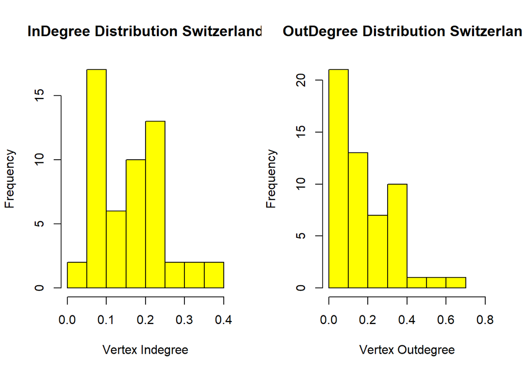

```r
par(mfrow=c(1,2))

hist (degree(coll.ch.net, mode = "in", normalized = TRUE), col="yellow", xlim=c(0,0.4),
      xlab = "Vertex Indegree", ylab="Frequency", main= "InDegree Distribution Switzerland")

hist (degree(coll.ch.net, mode = "out", normalized = TRUE), col="yellow", xlim=c(0,0.8),
      xlab = "Vertex Outdegree", ylab="Frequency", main= "OutDegree Distribution Switzerland")
```

Now for the influence network.

What do we see?

We see that the figures look very similar. Most actors are not percieved as influential, vice versa, and what makes sense, only few actors are considered as being influential.

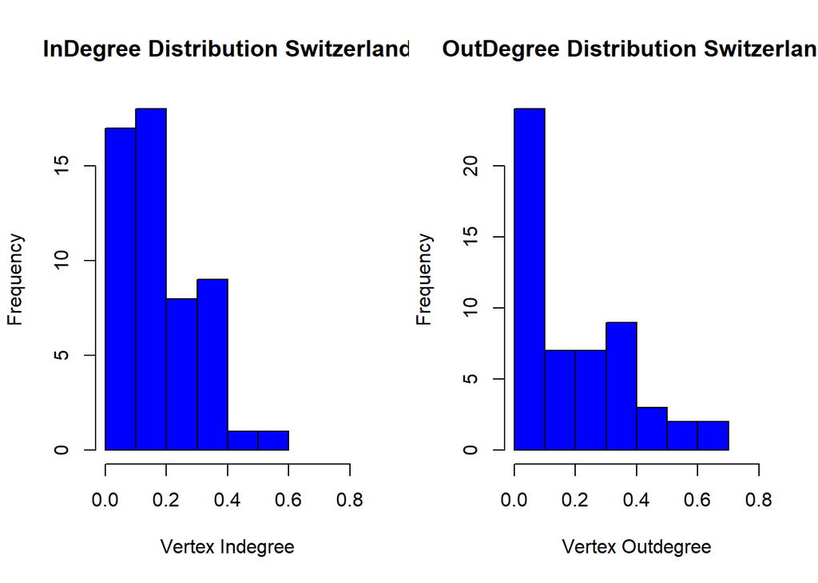

```r
par(mfrow=c(1,2))

hist (degree(inf.ch.net, mode = "in", normalized = TRUE), col="blue", xlim=c(0,0.8),
      xlab = "Vertex Indegree", ylab="Frequency", main= "InDegree Distribution Switzerland")

hist (degree(inf.ch.net, mode = "out", normalized = TRUE), col="blue", xlim=c(0,0.8),
      xlab = "Vertex Outdegree", ylab="Frequency", main= "OutDegree Distribution Switzerland")
```

6. Calculate network statistics (e.g. degree, betweenness, closeness, eigenvector) that make sense for your the respective networks - justify your selection. What do the stats mean in the respective context?

Again, we can replicate the code! I run them all for the collaboration network…

I have NaNs in the Closeness Centrality statistic. Why is that?

Which centrality stats make sense for the influence network?

```r
myCentrality <- function(net) {

  if (!is.igraph(net)) stop ("Input is not an igraph object")
  ideg <- degree (net, mode="in", loop=F, normalized = T)
  odeg <- degree (net, mode="out", loop=F, normalized = T)
  btw <- betweenness (net, normalized=TRUE)
  clo <- closeness (net, normalized=TRUE) # consider removing
  evc <- evcent(net)$vector
  id <- V(net)

  ret <-data.frame (cbind(IDegree=ideg, ODegree=odeg,
                         Betweenness=btw, Closeness=clo,
                          Eigenvector=evc, ID=id))
  return(ret)

}

Results_coll <- myCentrality(coll.ch.net)
Results_coll
```

```
##         IDegree    ODegree Betweenness Closeness Eigenvector ID
## CH1  0.03773585 0.24528302 0.001286312 0.5638298  0.33069409  1
## CH2  0.22641509 0.41509434 0.046410645 0.6162791  0.72313079  2
## CH3  0.13207547 0.00000000 0.000000000       NaN  0.20840614  3
## CH4  0.07547170 0.11320755 0.000919846 0.5000000  0.25418455  4
## CH5  0.09433962 0.37735849 0.020017163 0.6162791  0.41176613  5
## CH6  0.15094340 0.11320755 0.011305792 0.4344262  0.19933685  6
## CH7  0.13207547 0.22641509 0.008961296 0.4907407  0.35410727  7
## CH8  0.37735849 0.00000000 0.000000000       NaN  0.44670370  8
## CH9  0.24528302 0.20754717 0.026468495 0.5463918  0.45239373  9
## CH10 0.20754717 0.30188679 0.027268280 0.5578947  0.41625542 10
## CH11 0.24528302 0.13207547 0.027616553 0.4308943  0.42812989 11
## CH12 0.24528302 0.22641509 0.015727083 0.5463918  0.57950849 12
## CH13 0.16981132 0.30188679 0.007297836 0.5698925  0.62098163 13
## CH14 0.07547170 0.15094340 0.005427697 0.4529915  0.19063075 14
## CH15 0.24528302 0.24528302 0.017188600 0.5196078  0.56942704 15
## CH16 0.11320755 0.13207547 0.001613431 0.4690265  0.32990094 16
## CH17 0.32075472 0.67924528 0.120409980 0.7571429  1.00000000 17
## CH18 0.07547170 0.39622642 0.014784040 0.5578947  0.35757018 18
## CH19 0.07547170 0.09433962 0.001702346 0.3212121  0.19211670 19
## CH20 0.09433962 0.16981132 0.004426132 0.5145631  0.33384085 20
## CH21 0.11320755 0.13207547 0.021803188 0.4690265  0.27319858 21
## CH22 0.07547170 0.01886792 0.000359965 0.3212121  0.09911998 22
## CH23 0.22641509 0.01886792 0.000750743 1.0000000  0.35998625 23
## CH24 0.20754717 0.15094340 0.016018648 0.4953271  0.31944745 24
## CH25 0.09433962 0.30188679 0.006117415 0.5353535  0.44169072 25
## CH26 0.24528302 0.35849057 0.021476161 0.6091954  0.74926576 26
## CH27 0.03773585 0.18867925 0.001831295 0.5300000  0.22838317 27
## CH28 0.15094340 0.18867925 0.010318719 0.5247525  0.32620983 28
## CH29 0.16981132 0.05660377 0.003908572 0.7142857  0.25884949 29
## CH30 0.20754717 0.35849057 0.040512702 0.6022727  0.69624807 30
## CH31 0.15094340 0.20754717 0.011323342 0.4862385  0.34062070 31
## CH32 0.05660377 0.15094340 0.001344469 0.4649123  0.15979727 32
## CH33 0.09433962 0.13207547 0.010074284 0.4453782  0.21452314 33
## CH34 0.13207547 0.18867925 0.006888137 0.5463918  0.34209476 34
## CH35 0.18867925 0.32075472 0.017490115 0.5824176  0.67056038 35
## CH36 0.22641509 0.22641509 0.009228357 0.5463918  0.61761377 36
## CH37 0.26415094 0.50943396 0.042665214 0.6708861  0.91158346 37
## CH38 0.28301887 0.35849057 0.035906290 0.5955056  0.66433671 38
## CH39 0.22641509 0.33962264 0.018194743 0.5824176  0.63503550 39
## CH40 0.32075472 0.03773585 0.005377013 1.0000000  0.34587633 40
## CH41 0.35849057 0.00000000 0.000000000       NaN  0.36111686 41
## CH42 0.18867925 0.00000000 0.000000000       NaN  0.17875071 42
## CH43 0.20754717 0.00000000 0.000000000       NaN  0.20656507 43
## CH44 0.15094340 0.00000000 0.000000000       NaN  0.12249327 44
## CH45 0.09433962 0.00000000 0.000000000       NaN  0.09453956 45
## CH46 0.11320755 0.00000000 0.000000000       NaN  0.10664825 46
## CH47 0.18867925 0.00000000 0.000000000       NaN  0.18168593 47
## CH48 0.15094340 0.00000000 0.000000000       NaN  0.16634006 48
## CH49 0.09433962 0.00000000 0.000000000       NaN  0.06448682 49
## CH50 0.09433962 0.00000000 0.000000000       NaN  0.08665339 50
## CH51 0.09433962 0.00000000 0.000000000       NaN  0.08570753 51
## CH52 0.09433962 0.00000000 0.000000000       NaN  0.08044905 52
## CH53 0.05660377 0.00000000 0.000000000       NaN  0.03264636 53
## CH54 0.07547170 0.00000000 0.000000000       NaN  0.07992134 54
```

```r
# Round
Results_coll_r <- data.frame(apply(Results_coll[1:5],2, function(x) round(x, 3)))
Results_coll_r
```

```
##      IDegree ODegree Betweenness Closeness Eigenvector
## CH1    0.038   0.245       0.001     0.564       0.331
## CH2    0.226   0.415       0.046     0.616       0.723
## CH3    0.132   0.000       0.000       NaN       0.208
## CH4    0.075   0.113       0.001     0.500       0.254
## CH5    0.094   0.377       0.020     0.616       0.412
## CH6    0.151   0.113       0.011     0.434       0.199
## CH7    0.132   0.226       0.009     0.491       0.354
## CH8    0.377   0.000       0.000       NaN       0.447
## CH9    0.245   0.208       0.026     0.546       0.452
## CH10   0.208   0.302       0.027     0.558       0.416
## CH11   0.245   0.132       0.028     0.431       0.428
## CH12   0.245   0.226       0.016     0.546       0.580
## CH13   0.170   0.302       0.007     0.570       0.621
## CH14   0.075   0.151       0.005     0.453       0.191
## CH15   0.245   0.245       0.017     0.520       0.569
## CH16   0.113   0.132       0.002     0.469       0.330
## CH17   0.321   0.679       0.120     0.757       1.000
## CH18   0.075   0.396       0.015     0.558       0.358
## CH19   0.075   0.094       0.002     0.321       0.192
## CH20   0.094   0.170       0.004     0.515       0.334
## CH21   0.113   0.132       0.022     0.469       0.273
## CH22   0.075   0.019       0.000     0.321       0.099
## CH23   0.226   0.019       0.001     1.000       0.360
## CH24   0.208   0.151       0.016     0.495       0.319
## CH25   0.094   0.302       0.006     0.535       0.442
## CH26   0.245   0.358       0.021     0.609       0.749
## CH27   0.038   0.189       0.002     0.530       0.228
## CH28   0.151   0.189       0.010     0.525       0.326
## CH29   0.170   0.057       0.004     0.714       0.259
## CH30   0.208   0.358       0.041     0.602       0.696
## CH31   0.151   0.208       0.011     0.486       0.341
## CH32   0.057   0.151       0.001     0.465       0.160
## CH33   0.094   0.132       0.010     0.445       0.215
## CH34   0.132   0.189       0.007     0.546       0.342
## CH35   0.189   0.321       0.017     0.582       0.671
## CH36   0.226   0.226       0.009     0.546       0.618
## CH37   0.264   0.509       0.043     0.671       0.912
## CH38   0.283   0.358       0.036     0.596       0.664
## CH39   0.226   0.340       0.018     0.582       0.635
## CH40   0.321   0.038       0.005     1.000       0.346
## CH41   0.358   0.000       0.000       NaN       0.361
## CH42   0.189   0.000       0.000       NaN       0.179
## CH43   0.208   0.000       0.000       NaN       0.207
## CH44   0.151   0.000       0.000       NaN       0.122
## CH45   0.094   0.000       0.000       NaN       0.095
## CH46   0.113   0.000       0.000       NaN       0.107
## CH47   0.189   0.000       0.000       NaN       0.182
## CH48   0.151   0.000       0.000       NaN       0.166
## CH49   0.094   0.000       0.000       NaN       0.064
## CH50   0.094   0.000       0.000       NaN       0.087
## CH51   0.094   0.000       0.000       NaN       0.086
## CH52   0.094   0.000       0.000       NaN       0.080
## CH53   0.057   0.000       0.000       NaN       0.033
## CH54   0.075   0.000       0.000       NaN       0.080
```

```r
Results_inf <- myCentrality(inf.ch.net)
Results_inf
```

```
##         IDegree    ODegree  Betweenness Closeness Eigenvector ID
## CH1  0.05660377 0.20754717 2.069543e-03 0.4862385  0.24116113  1
## CH2  0.18867925 0.41509434 1.132353e-02 0.6309524  0.66912103  2
## CH3  0.03773585 0.05660377 2.267779e-05 0.4491525  0.12235871  3
## CH4  0.05660377 0.33962264 1.622488e-03 0.5824176  0.39999349  4
## CH5  0.13207547 0.33962264 6.004368e-03 0.5824176  0.51514095  5
## CH6  0.22641509 0.18867925 9.128175e-03 0.4907407  0.45675140  6
## CH7  0.05660377 0.37735849 4.013388e-03 0.6162791  0.49680886  7
## CH8  0.50943396 0.00000000 0.000000e+00       NaN  0.55820732  8
## CH9  0.39622642 0.32075472 2.695573e-02 0.5824176  0.73834322  9
## CH10 0.15094340 0.33962264 1.136892e-02 0.5578947  0.51727244 10
## CH11 0.18867925 0.22641509 5.024037e-03 0.5638298  0.50402277 11
## CH12 0.35849057 0.15094340 7.555148e-03 0.4774775  0.55688361 12
## CH13 0.24528302 0.52830189 2.738942e-02 0.6708861  0.81050894 13
## CH14 0.33962264 0.33962264 2.725963e-02 0.5824176  0.72523579 14
## CH15 0.20754717 0.69811321 7.112061e-02 0.7681159  0.85493755 15
## CH16 0.15094340 0.03773585 8.877996e-04 0.3605442  0.23539849 16
## CH17 0.47169811 0.67924528 1.725912e-01 0.7571429  1.00000000 17
## CH18 0.20754717 0.15094340 2.360213e-03 0.4206349  0.39667144 18
## CH19 0.09433962 0.16981132 1.263536e-03 0.5463918  0.34455427 19
## CH20 0.16981132 0.28301887 1.173821e-02 0.5760870  0.52145932 20
## CH21 0.32075472 0.03773585 1.321360e-03 0.3581081  0.41876076 21
## CH22 0.03773585 0.03773585 1.324671e-04 0.4416667  0.10366259 22
## CH23 0.15094340 0.00000000 0.000000e+00       NaN  0.20557452 23
## CH24 0.32075472 0.13207547 8.904602e-03 0.4649123  0.47820522 24
## CH25 0.11320755 0.26415094 1.543476e-02 0.5578947  0.39731800 25
## CH26 0.28301887 0.54716981 4.783172e-02 0.6883117  0.83224124 26
## CH27 0.11320755 0.20754717 7.858524e-03 0.5353535  0.36342561 27
## CH28 0.05660377 0.39622642 3.495746e-03 0.6235294  0.50635314 28
## CH29 0.05660377 0.00000000 0.000000e+00       NaN  0.07165806 29
## CH30 0.22641509 0.41509434 1.641653e-02 0.6309524  0.67045694 30
## CH31 0.20754717 0.22641509 4.046487e-03 0.5463918  0.51171828 31
## CH32 0.09433962 0.22641509 3.965447e-03 0.4818182  0.30149688 32
## CH33 0.01886792 0.05660377 0.000000e+00 0.4690265  0.10293189 33
## CH34 0.11320755 0.45283019 8.294477e-03 0.6309524  0.58121771 34
## CH35 0.13207547 0.32075472 6.338285e-03 0.5955056  0.55309770 35
## CH36 0.16981132 0.09433962 9.939225e-04 0.4690265  0.32466386 36
## CH37 0.39622642 0.32075472 2.895690e-02 0.5520833  0.70903453 37
## CH38 0.26415094 0.16981132 1.595087e-02 0.4206349  0.38087923 38
## CH39 0.33962264 0.13207547 4.610671e-02 0.5000000  0.48082100 39
## CH40 0.32075472 0.00000000 0.000000e+00       NaN  0.33883781 40
## CH41 0.33962264 0.00000000 0.000000e+00       NaN  0.35544404 41
## CH42 0.16981132 0.00000000 0.000000e+00       NaN  0.17005582 42
## CH43 0.18867925 0.00000000 0.000000e+00       NaN  0.21610759 43
## CH44 0.15094340 0.00000000 0.000000e+00       NaN  0.18742173 44
## CH45 0.09433962 0.00000000 0.000000e+00       NaN  0.12538853 45
## CH46 0.11320755 0.00000000 0.000000e+00       NaN  0.17067911 46
## CH47 0.18867925 0.00000000 0.000000e+00       NaN  0.23528651 47
## CH48 0.15094340 0.00000000 0.000000e+00       NaN  0.17399092 48
## CH49 0.09433962 0.00000000 0.000000e+00       NaN  0.10702896 49
## CH50 0.09433962 0.00000000 0.000000e+00       NaN  0.09687209 50
## CH51 0.09433962 0.00000000 0.000000e+00       NaN  0.12146534 51
## CH52 0.09433962 0.00000000 0.000000e+00       NaN  0.11600931 52
## CH53 0.05660377 0.00000000 0.000000e+00       NaN  0.06734566 53
## CH54 0.07547170 0.00000000 0.000000e+00       NaN  0.08903391 54
```

```r
# Round
Results_inf_r <- data.frame(apply(Results_inf[1:5],2, function(x) round(x, 3)))
Results_inf_r
```

```
##      IDegree ODegree Betweenness Closeness Eigenvector
## CH1    0.057   0.208       0.002     0.486       0.241
## CH2    0.189   0.415       0.011     0.631       0.669
## CH3    0.038   0.057       0.000     0.449       0.122
## CH4    0.057   0.340       0.002     0.582       0.400
## CH5    0.132   0.340       0.006     0.582       0.515
## CH6    0.226   0.189       0.009     0.491       0.457
## CH7    0.057   0.377       0.004     0.616       0.497
## CH8    0.509   0.000       0.000       NaN       0.558
## CH9    0.396   0.321       0.027     0.582       0.738
## CH10   0.151   0.340       0.011     0.558       0.517
## CH11   0.189   0.226       0.005     0.564       0.504
## CH12   0.358   0.151       0.008     0.477       0.557
## CH13   0.245   0.528       0.027     0.671       0.811
## CH14   0.340   0.340       0.027     0.582       0.725
## CH15   0.208   0.698       0.071     0.768       0.855
## CH16   0.151   0.038       0.001     0.361       0.235
## CH17   0.472   0.679       0.173     0.757       1.000
## CH18   0.208   0.151       0.002     0.421       0.397
## CH19   0.094   0.170       0.001     0.546       0.345
## CH20   0.170   0.283       0.012     0.576       0.521
## CH21   0.321   0.038       0.001     0.358       0.419
## CH22   0.038   0.038       0.000     0.442       0.104
## CH23   0.151   0.000       0.000       NaN       0.206
## CH24   0.321   0.132       0.009     0.465       0.478
## CH25   0.113   0.264       0.015     0.558       0.397
## CH26   0.283   0.547       0.048     0.688       0.832
## CH27   0.113   0.208       0.008     0.535       0.363
## CH28   0.057   0.396       0.003     0.624       0.506
## CH29   0.057   0.000       0.000       NaN       0.072
## CH30   0.226   0.415       0.016     0.631       0.670
## CH31   0.208   0.226       0.004     0.546       0.512
## CH32   0.094   0.226       0.004     0.482       0.301
## CH33   0.019   0.057       0.000     0.469       0.103
## CH34   0.113   0.453       0.008     0.631       0.581
## CH35   0.132   0.321       0.006     0.596       0.553
## CH36   0.170   0.094       0.001     0.469       0.325
## CH37   0.396   0.321       0.029     0.552       0.709
## CH38   0.264   0.170       0.016     0.421       0.381
## CH39   0.340   0.132       0.046     0.500       0.481
## CH40   0.321   0.000       0.000       NaN       0.339
## CH41   0.340   0.000       0.000       NaN       0.355
## CH42   0.170   0.000       0.000       NaN       0.170
## CH43   0.189   0.000       0.000       NaN       0.216
## CH44   0.151   0.000       0.000       NaN       0.187
## CH45   0.094   0.000       0.000       NaN       0.125
## CH46   0.113   0.000       0.000       NaN       0.171
## CH47   0.189   0.000       0.000       NaN       0.235
## CH48   0.151   0.000       0.000       NaN       0.174
## CH49   0.094   0.000       0.000       NaN       0.107
## CH50   0.094   0.000       0.000       NaN       0.097
## CH51   0.094   0.000       0.000       NaN       0.121
## CH52   0.094   0.000       0.000       NaN       0.116
## CH53   0.057   0.000       0.000       NaN       0.067
## CH54   0.075   0.000       0.000       NaN       0.089
```

7. Which actor group is most central in the collaboration network? Which is perceived as most influential? Who is the most influential actor? Who collaborates most? Who is most the most popular collaboration target?

```r
library(tidyverse)

Results_coll_r$actor.type <- types.ch$Type

Group_cent_coll <- Results_r %>%
   mutate(actor.type = recode(actor.type, "1" = "GOV",
         "2" = "SCI",
         "3" = "BUS", "4" = "CIV", "5"="NA")) %>%
  group_by(actor.type) %>%
  summarise(mean_OD = mean(ODegree),  mean_ID = mean(IDegree), mean_Betw = mean(Betweenness), mean_clo=mean(Closeness), mean_Eig=mean(Eigenvector))
Group_cent_coll
```

```
## # A tibble: 5 × 6
##   actor.type mean_OD mean_ID mean_Betw mean_clo mean_Eig
##   <fct>        <dbl>   <dbl>     <dbl>    <dbl>    <dbl>
## 1 GOV         0.0669  0.110    0.00333      NaN    0.226
## 2 SCI         0.0976  0.0924   0.00521      NaN    0.220
## 3 BUS         0.0934  0.0865   0.00272      NaN    0.209
## 4 CIV         0.190   0.112    0.01         NaN    0.368
## 5 <NA>        0       0.098    0            NaN    0.152
```

```r
library(tidyverse)

Results_inf_r$actor.type <- types.ch$Type

Group_cent_inf <- Results_r %>%
   mutate(actor.type = recode(actor.type, "1" = "GOV",
         "2" = "SCI",
         "3" = "BUS", "4" = "CIV", "5"="NA")) %>%
  group_by(actor.type) %>%
  summarise(mean_OD = mean(ODegree),  mean_ID = mean(IDegree), mean_Betw = mean(Betweenness), mean_clo=mean(Closeness), mean_Eig=mean(Eigenvector))
Group_cent_inf
```

```
## # A tibble: 5 × 6
##   actor.type mean_OD mean_ID mean_Betw mean_clo mean_Eig
##   <fct>        <dbl>   <dbl>     <dbl>    <dbl>    <dbl>
## 1 GOV         0.0669  0.110    0.00333      NaN    0.226
## 2 SCI         0.0976  0.0924   0.00521      NaN    0.220
## 3 BUS         0.0934  0.0865   0.00272      NaN    0.209
## 4 CIV         0.190   0.112    0.01         NaN    0.368
## 5 <NA>        0       0.098    0            NaN    0.152
```

```r
detach(package:igraph) # igraph will cause confusion with other packages, hence we need to detach it.
library(sna) # another network package;
library(GGally)
library(network) # another network package;
library(ggplot2) # for plotting
library(RColorBrewer)
library(intergraph) # another network package;
library(scales)
library(tidyverse) # data management

net <- network(coll.ch.mat, directed = TRUE) # this is a different way to create a graph object (using the network package);

# To add attributes here:

net%v%"actorType" <- types.ch$Type

unique(types.ch$Type)
```

```
## [1] "Business"      "Civil society" "Government"    "Science"
## [5] "Party"
```

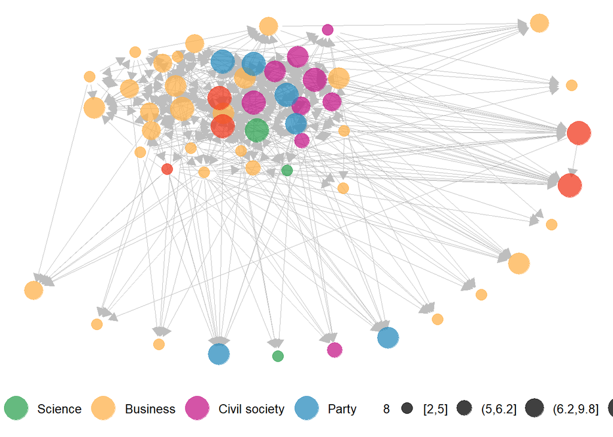

```r
# Adjust your color palette (tip: https://colorbrewer2.org/#type=sequential&scheme=BuGn&n=3)!
# Unique actor types: "Business" "Civil society" "Government"    "Science"       "Party"

# Exmple on how to create a color palette for the actor type variable

palette = c("Government" = "#f03b20", "Science" = "#31a354",
             "Business" ="#feb24c", "Civil society" = "#c51b8a", "Party" = "#2b8cbe")

# Adjust this code to your taste! If you don't know what to do, go and ask Dr. Google!

ggnet2(net, alpha = 0.75, label = FALSE, label.size = 3, mode = "kamadakawai", node.size = 6, size = "indegree", color = "actorType",
       arrow.size = 8, arrow.gap = 0.025,
       shape.legend = "Actor Type",
       color.legend = "actorType", edge.color = "grey", # maybe you have to adjust the name of the actorType variable here
       palette = palette,
       legend.size = 10, size.min = 1, size.cut = 5, size.legend = "8", legend.position = "bottom")
```

```r
ggsave("Plots/my_CH_network.png", width = 29, height = 18,  device = NULL, dpi = 300)
```